# Students Performance

# 2/10/2021

## Students Performance

## Project Proposal and Scope

This jupyter notebook and libraries looks into using various Python based machine learning and data science machine learning model to help us to predict what the factors that affect the test score of students in various subjects. And if there are any way to deal with this factor or reduce their rosks.

## Introduction

A school wants to analysis their students performance in test and what kind of factors that can affect them. And if the preparation test scores are higher than the real test score or if it lower of the test score. What kinds of factors that accours that affect the test score.

## Project goals

To know if the ents level education background have effects on the test score of their children

Clustring the realtionship between test preparetion and the performance in the real test

Identify who has the highest test score male or females

Identify what test has the highest score and what test has the lower score

## Questions

Is the parents education has affect on the children scores?

Who have higher chances of having the highest Male or Females?

Doest the students who attended test preparetion havr the highest score ?

Identify the test that students perform goid in it and the test the students perform the worst in it?

## data Source

http://roycekimmons.com/tools/generated_data/exams

## evaluation

Is trying to aarive to 95% to predict what is the factor that effects the students scores whether there is a way to deal with the factors. We"ll continues in the process of the project if we did not arrive to 95% we will restart the process of the project with new approach.

## Features

gender  
race/ethnicity  
parental level of education lunch  
test preparation course math score  
reading score  
writing score

## libraries used

np

pd

plt

random

sns

sb

os

data time

glob

matplotlib

# What is the structure of your dataset?

it contains 10 columns and 1000 rows.

# What is/are the main feature(s) of interest in your dataset?

gender, parental level of education and test preparation course

# What features in the dataset do you think will help support your investigation into your feature(s) of interest?

Sparental level of education and students scores because it show that the parents education affected on the students performance and test preparation because it helps the school to know if this course help or it is useless and need to change it

# Data Exploration

The goal here is to find out more about the data and become a subject matter export on the dataset we are working with

What questions are we trying to solve?

What kind of data do we have and how do we treat different types?

What's missing from the data and how do we deal with it ?

Where are the outliers and why should we care about that?

How can we add, change or remove features to get more out of our data?

# Students Performance Frequency according to parents educational background

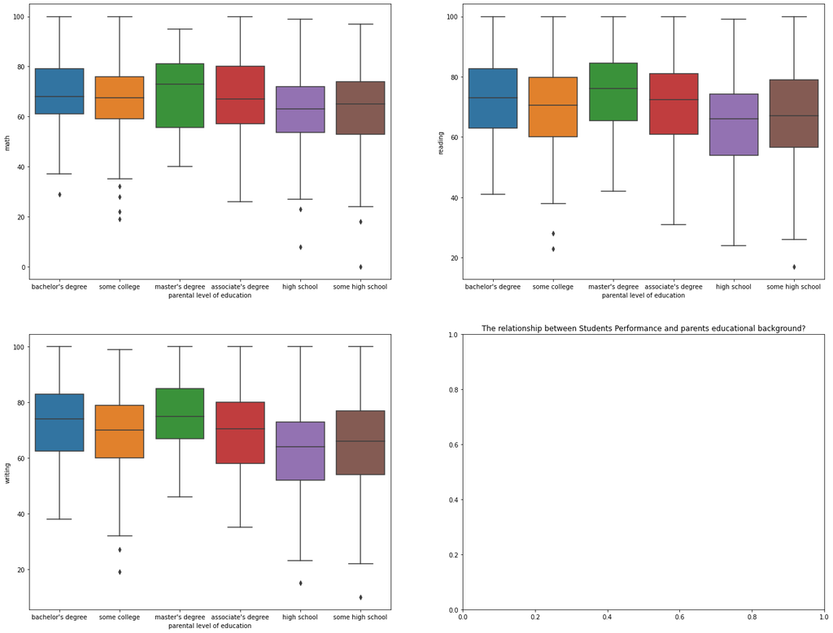

```python
fig, axs = plt.subplots(2, 2, figsize=(23, 18))

sns.boxplot( x=df['parental level of education'], y=df['math'], ax=axs[0,0]);
sns.boxplot( x=df['parental level of education'], y=df['reading'], ax=axs[0,1]);
sns.boxplot( x=df['parental level of education'], y=df['writing'], ax=axs[1,0]);
plt.title("The relationship between Students Performance and parents educational background?")
```

# the affects of the parents educational background on Students Performance?

# Students Performance VS. Gender

[figure not shown]

```python
plt.figure(figsize = [10, 10])
sorted_counts = df['gender'].value_counts()
plt.pie(sorted_counts, labels = sorted_counts.index, startangle = 90, counterclock = False,autopct='%.1f%%');
plt.axis('square');
plt.title('Proportion of Female and Male?')
```

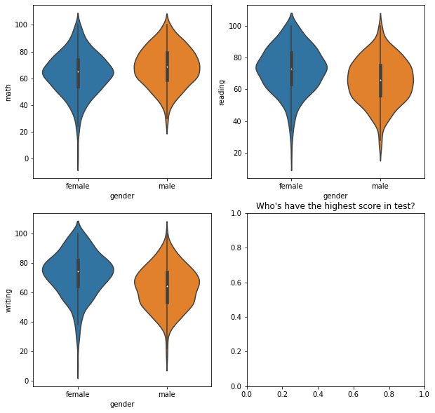

```python
fig, axs = plt.subplots(2, 2, figsize=(10, 10))

sb.violinplot( x=df['gender'], y=df['math'], ax=axs[0,0]);
sb.violinplot( x=df['gender'], y=df['reading'], ax=axs[0,1]);
sb.violinplot( x=df['gender'], y=df['writing'], ax=axs[1,0]);
plt.title("Who's have the highest score in test?")
```

# The students performance depending on the genders?

# Summary